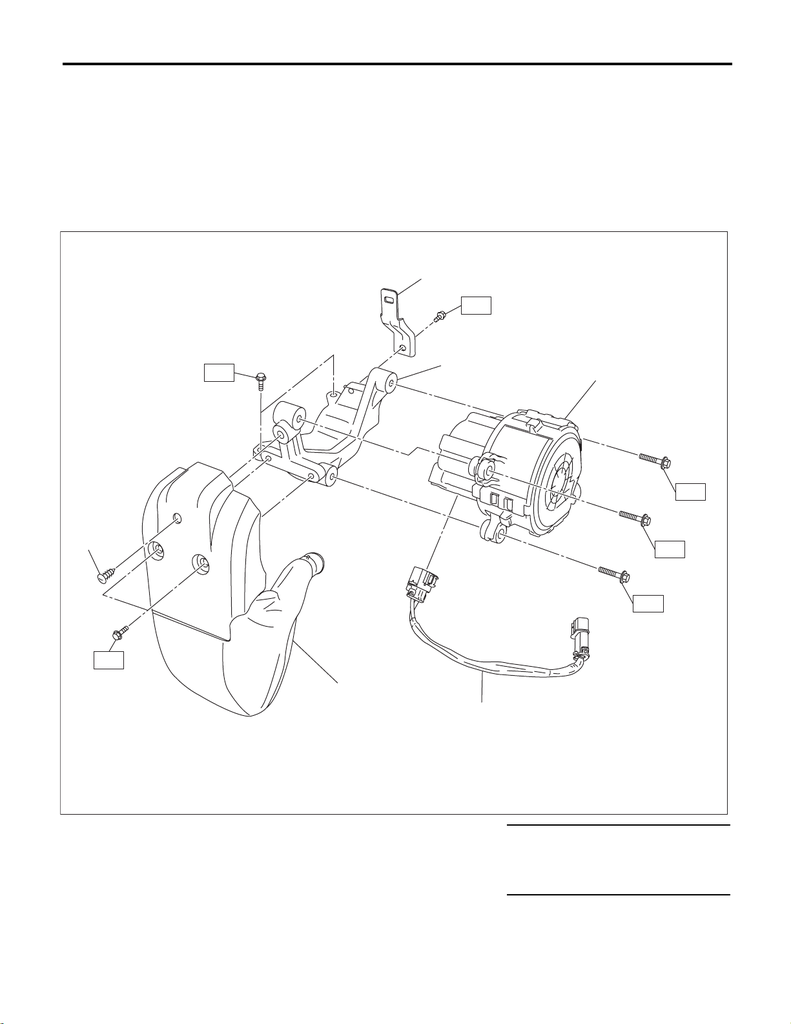

EC(STI)-2

General Description

EMISSION CONTROL (AUX. EMISSION CONTROL DEVICES)

1. General Description

A: COMPONENT

1. CANISTER, PURGE CONTROL SOLENOID VALVE, DRAIN FILTER AND LEAK CHECK

VALVE ASSEMBLY

For components of canister, purge control solenoid valve, drain filter and leak check valve assembly, refer to

FU (STI). <Ref. to FU(STI)-3, COMPONENT, General Description.>

2. SECONDARY AIR PUMP

(1) Secondary air pump (4) Resonator Tightening torque: N·m (kgf-m, ft-lb)

(2) Clip (5) Harness stay T1: 6.4 (0.7, 4.7)

(3) Secondary air pump bracket (6) Secondary air pump harness T2: 9 (0.9, 6.6)

T3: 19 (1.9, 14.0)

EC-02684

(3)

T2

T2

T2

T3

(4)

(2)

T1

T1

(6)

(5)

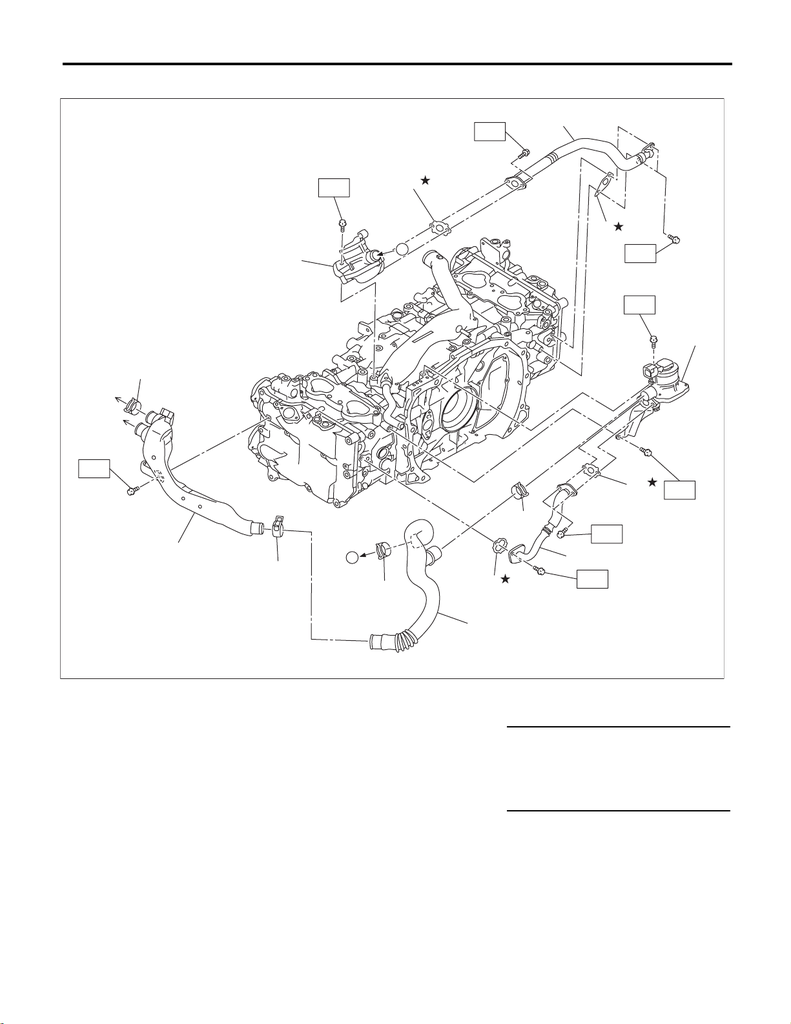

EC(STI)-3

General Description

EMISSION CONTROL (AUX. EMISSION CONTROL DEVICES)

3. SECONDARY AIR COMBINATION VALVE

(A) To secondary air pump (B) To resonator

(1) Gasket (7) Air duct A Tightening torque: N·m (kgf-m, ft-lb)

(2) Gasket (8) Air duct B T1: 6.4 (0.7, 4.7)

(3) Gasket (9) Secondary air combination valve

LH

T2: 9 (0.9, 6.6)

(4) Clip (10) Secondary air pipe LH T3: 19 (1.9, 14.0)

(5) Secondary air pipe RH (11) Gasket

(6) Secondary air combination valve

RH

EC-02717

(2)

T2

T3

T2

T3

T3

T2

T3

T1

(3)

(4)

(4)

(4)

(5)

(6)

(7)

(8)

(9)

(10)

(11)

(4)

(A)

(B)

A

A

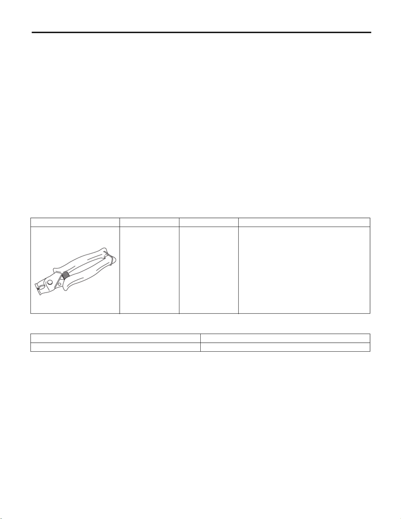

EC(STI)-4

General Description

EMISSION CONTROL (AUX. EMISSION CONTROL DEVICES)

B: CAUTION

• Prior to starting work, pay special attention to the following:

1. Always wear work clothes, a work cap, and protective shoes. Additionally, wear a helmet, protective

goggles, etc. if necessary.

2. Protect the vehicle using a seat cover, fender cover, etc.

3. Prepare the service tools, clean cloth, containers to catch grease and oil, etc.

• Vehicle components are extremely hot immediately after driving. Be wary of receiving burns from heated

parts.

• When performing a repair, identify the cause of trouble and avoid unnecessary removal, disassembly and

replacement.

• Before disconnecting connectors of sensors or units, be sure to disconnect the ground cable from battery.

• Always use the jack-up point when the shop jacks or rigid racks are used to support the vehicle.

• Remove contamination including dirt and corrosion before removal, installation, disassembly or assembly.

• Keep the removed parts in order and protect them from dust and dirt.

• All removed parts, if to be reused, should be reinstalled in the original positions with attention to the correct

directions, etc.

• Bolts, nuts and washers should be replaced with new parts as required.

• Be sure to tighten the fasteners including bolts and nuts to the specified torque.

C: PREPARATION TOOL

1. SPECIAL TOOL

2. GENERAL TOOL

ILLUSTRATION TOOL NUMBER DESCRIPTION REMARKS

18353AA000 CLAMP PLIERS • Used for removing and installing the PCV

hose.

• This tool is made by the French company

CAILLAU. (code) 54.0.000.205

To make it easier to obtain, it has been provided

with a tool number.

TOOL NAME REMARKS

Circuit tester Used for measuring resistance.

ST18353AA000